# Cluster analysis

Mar 10 2026

## Chapters for cluster analysis

**ISLR: Chapter 12**: Unsupervised Learning

o Section 12.4: Clustering Methods

§ Section 12.4.1: K-Means Clustering

§ Section 12.4.2: Hierarchical Clustering

**R Book: Chapter 25**: Multivariate Statistics

o Section 25.3: Cluster Analysis

§ Section 25.3.1: Partitioning

§ Section 25.3.2: Taxonomic Use of K-means

o Section 25.4: Hierarchical Cluster Analysis

## Topics for this lecture

- Cluster analysis
- Similarity and distance
- K-means clustering
- Partitioning Around Medoids (PAM) clustering
- Hierarchical clustering
- Case study: Assignment 1

## Cluster analysis

- Objects belong to some groups or classes
- Cluster analysis is so-called *Unsupervised learning* of groups
- Neither the identity nor the number of groups is known
- Can be a non-parametric (algorithmic) data-driven search - today
- Or statistical grounded through semi-parametric mixture models - advanced
- Later in the course, we will return to *supervised learning* where the identities and number of groups are known (discriminant analysis and classification)

## Groups in data

- A data set with \(n\) cases (rows) and \(p\) variables (columns)\(\mathbf{X} = \begin{bmatrix} x_{11} & \cdots & x_{1p} \\ \vdots & \vdots & \vdots \\ x_{n1} & \cdots & x_{np} \end{bmatrix}\)
- We look for groups in the data cases
  - Cases in the same group are «similar»
  - Cases in different groups are «different»
- Grouping or similarity is relative to some **similarity** or **distance metric**
  - What do we mean by the «distance» between two points?

## Motivation

- **Explorative**
  - A way to «inspect» large data sets
  - May give you some ideas/hypotheses
  - May reveal outliers or severe errors in data
- **Down-sampling**
  - Each cluster center is a representative of its «region» in the data

## Measure of similarity/dissimilarity

We need measures of “distance” between observations

- Euclidean distance
- Manhattan distance
- Minkowski distance
- Hamming distance (for binary variables)
- Others

See e.g `?dist` for R help

## A simulated example - Distance between observations?

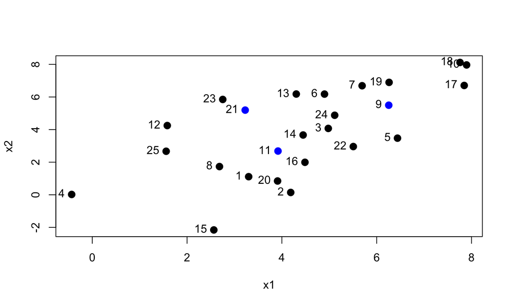

## Euclidean distance

Euclidean distance is shortest distance on a map

E.g. distance between two observations \((x_{11}, x_{12})\) and \((x_{21}, x_{22})\)

\[D_e = \sqrt{(x_{11} - x_{21})^2 + (x_{12} - x_{22})^2}\]

## Euclidean distance: example

Assume \(x_1 = (6.255,5.495), x_2 = (3.919,2.683)\)

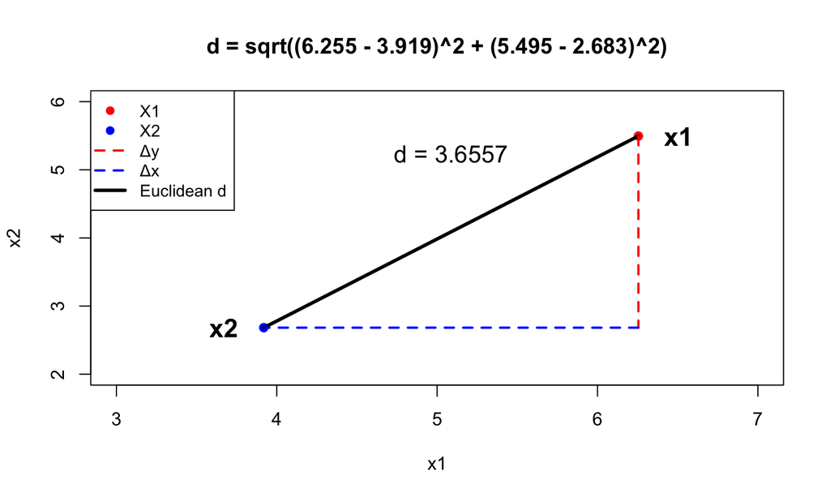

## For blue observations no (9, 11 and 21)

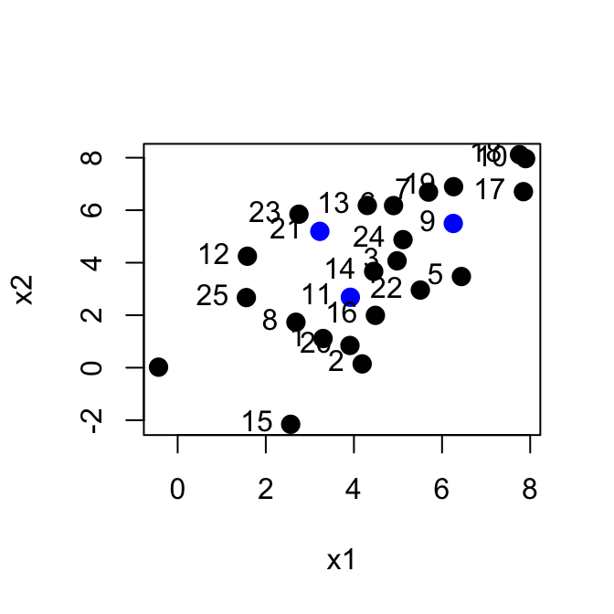

```r
dist(mypoints, method ="euclidean")
```

```
##           9       11
## 11 3.655337
## 21 3.043111 2.604636
```

## Manhattan distance

“Manhattan distance”” is like the walking distance between two shops on Manhattan

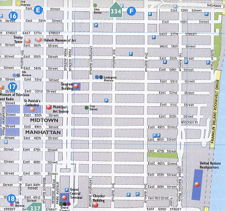

## Manhattan distance, continued

Manhattan distance between two observations \(x_1 = (6.255,5.495), x_2 = (3.919,2.683)\)

\[D_m = |x_{11} - x_{21}| + |x_{12} - x_{22}|\]

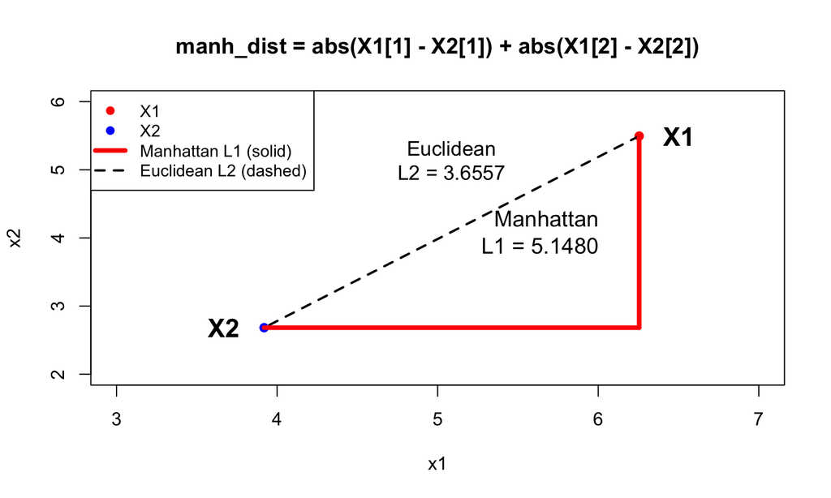

## Manhattan distance for blue points:

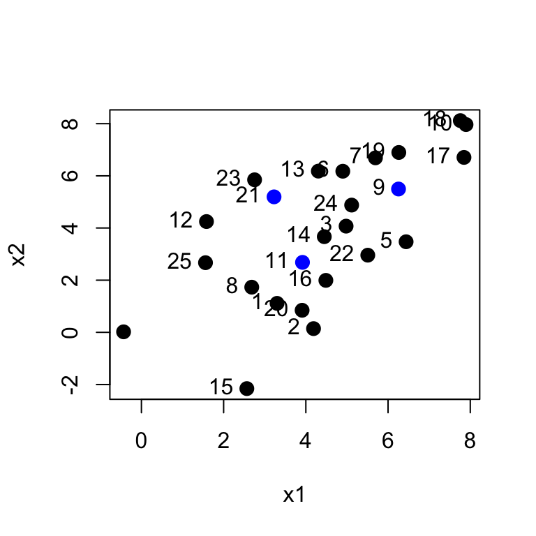

```
##           9       11
## 11 5.147513
## 21 3.328770 3.203190
```

## Minkowski distance

For two points \(\mathbf{x}_1 = (x_{11},\dots,x_{1p})\) and \(\mathbf{x}_2 = (x_{21},\dots,x_{2p})\), the **Minkowski distance** of order \(r \ge 1\) is \[ d_r(\mathbf{x}_1, \mathbf{x}_2) = \left( \sum_{j=1}^p |x_{1j} - x_{2j}|^r \right)^{1/r}. \]

- **Manhattan distance** (\(r = 1\)): \(d_1(\mathbf{x}_1, \mathbf{x}_2) = \sum_{j=1}^p |x_{1j} - x_{2j}|\)
- **Euclidean distance** (\(r = 2\)): \(d_2(\mathbf{x}_1, \mathbf{x}_2) = \sqrt{\sum_{j=1}^p (x_{1j} - x_{2j})^2}\)
- Larger \(r\) values give more weight to large coordinate differences.

## Hamming distance

For two **binary** vectors \(\mathbf{x}_1, \mathbf{x}_2 \in \{0,1\}^p\) of the same length, the **Hamming distance** counts how many positions differ: \[ d_H(\mathbf{x}_1, \mathbf{x}_2) = \#\{j : x_{1j} \ne x_{2j}\}. \]

**Example** (differences highlighted in red):

\[ \mathbf{x}_1 = \left( \color{red}{1},\, 0,\, \color{red}{1},\, 0 \right), \quad \mathbf{x}_2 = \left( \color{red}{0},\, 0,\, \color{red}{0},\, 0 \right) \]

Positions 1 and 3 differ, so \(d_H(\mathbf{x}_1, \mathbf{x}_2) = 2\).

- Used for **categorical** or **binary** variables (e.g., gene sequences, binary features).
- Related to the number of bit flips needed to transform one vector into the other.

## Iris data

Goal: Group together objects that are similar

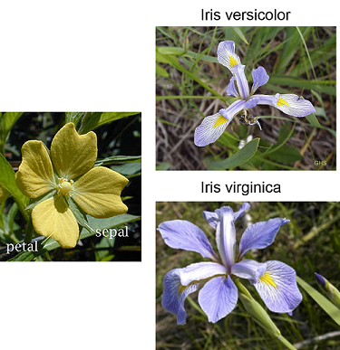

## The famous “Iris” data set

- This famous (Fisher’s or Anderson’s) iris data set gives the measurements in centimeters of the variables X1=sepal length, X2=sepal width, X3=petal length and X4=petal width, respectively.

```
##     Sepal.Length Sepal.Width Petal.Length Petal.Width    Species
## 1            5.1         3.5          1.4         0.2     setosa
## 2            4.9         3.0          1.4         0.2     setosa
## 3            4.7         3.2          1.3         0.2     setosa
## 55           6.5         2.8          4.6         1.5 versicolor
## 56           5.7         2.8          4.5         1.3 versicolor
## 57           6.3         3.3          4.7         1.6 versicolor
## 125          6.7         3.3          5.7         2.1  virginica
## 126          7.2         3.2          6.0         1.8  virginica
```

- Question: Are there many species of iris? which are which? (if we did not know the truth)

## Sepal vs petal length/width

- Are there detectable clusters in the data?

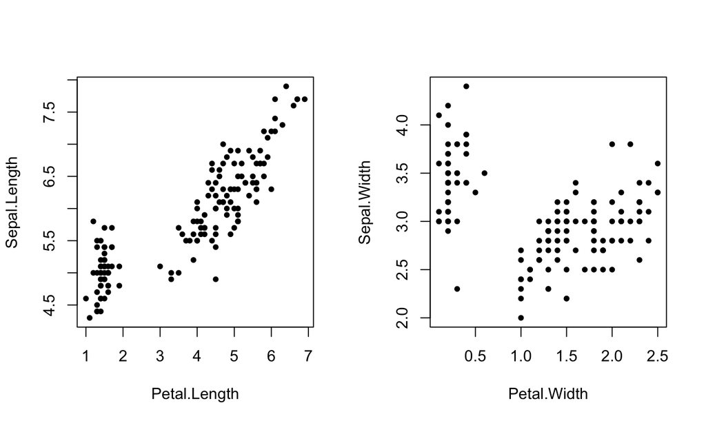

## For these data we know…

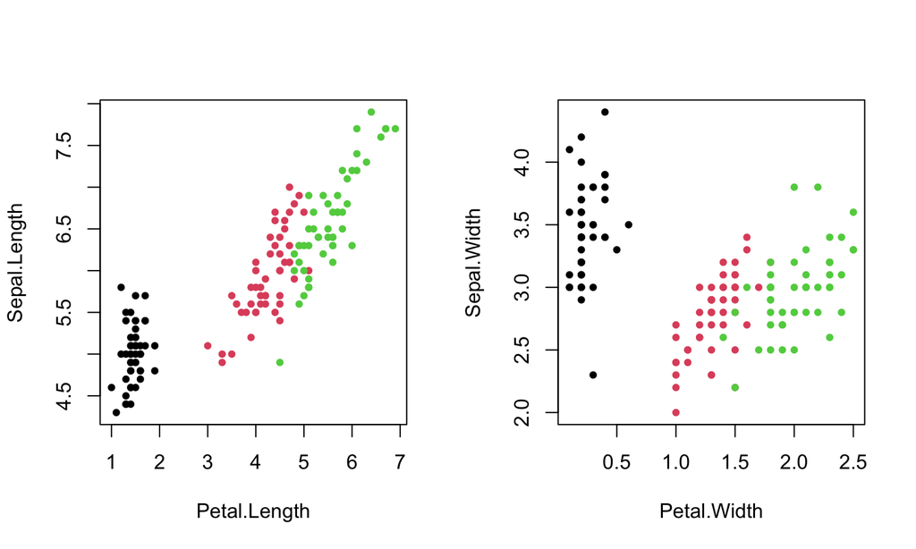

## K-means clustering

- Distribute the observations into \(K\) clusters so that the **within-cluster** dissimilarity (from **Euclidean distance**) is minimized.
- For cluster \(C_k\), the within-cluster sum of squared distances is \[ W(C_k) = \sum_{\mathbf{x}_i \in C_k} d^2(\mathbf{x}_i, \boldsymbol{\mu}_k), \] where \(d(\cdot,\cdot)\) is the distance (here Euclidean) and \(\boldsymbol{\mu}_k\) is the centroid of \(C_k\).
- The k-means objective is to find clusters \(C_1, \dots, C_K\) such that\[ \text{WCSS}_K=\sum_{k=1}^K W(C_k)\rightarrow\min. \]

## K-means illustrated, I

- Two variables, x1 and x2, and \(K=3\) clusters

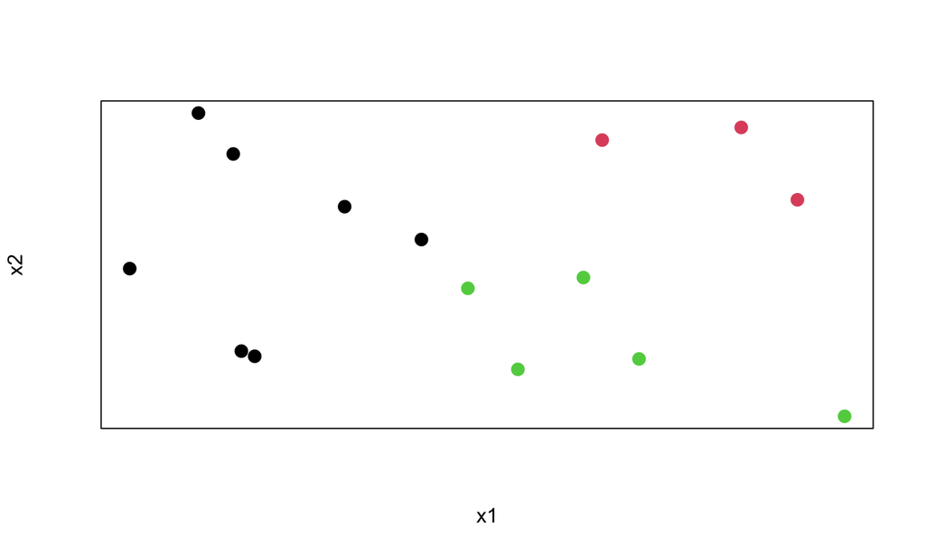

## K-means clustering algorithm

1. Choose the number of clusters \(K\) and select \(K\) initial centroids (typically random observations).
2. **Assignment step**: Assign each observation to the cluster with the closest centroid (Euclidean distance).
3. **Update step**: Recompute each centroid as the mean of the observations currently in that cluster.
4. Repeat steps 2–3 until the cluster assignments no longer change.
- Sensitive to the random starting centroids → may converge to a **local** minimum; therefore run k-means several times and keep the best solution.

## K-means: Step 0

Initial data, no clusters yet.

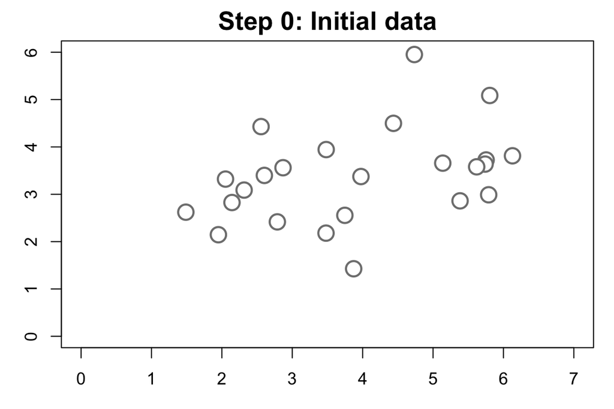

## K-means: Step 1

**Initialize**: Randomly place \(K = 2\) centroids.

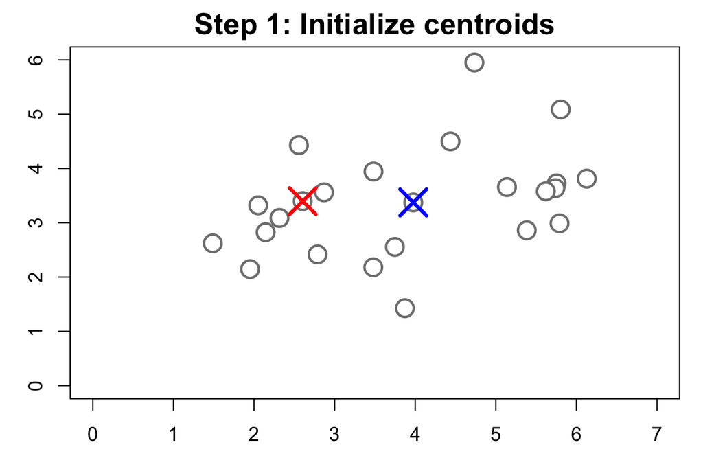

## K-means: Step 2

**Assign** each observation to the nearest centroid.

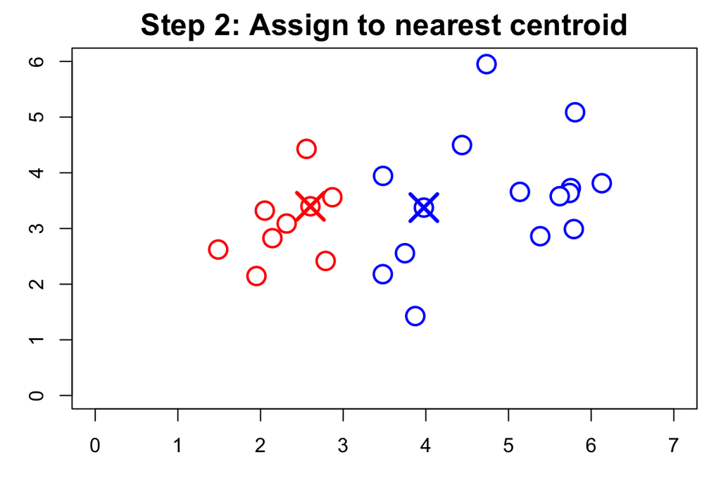

## K-means: Step 3

**Update**: Compute new centroids as the mean of assigned points.

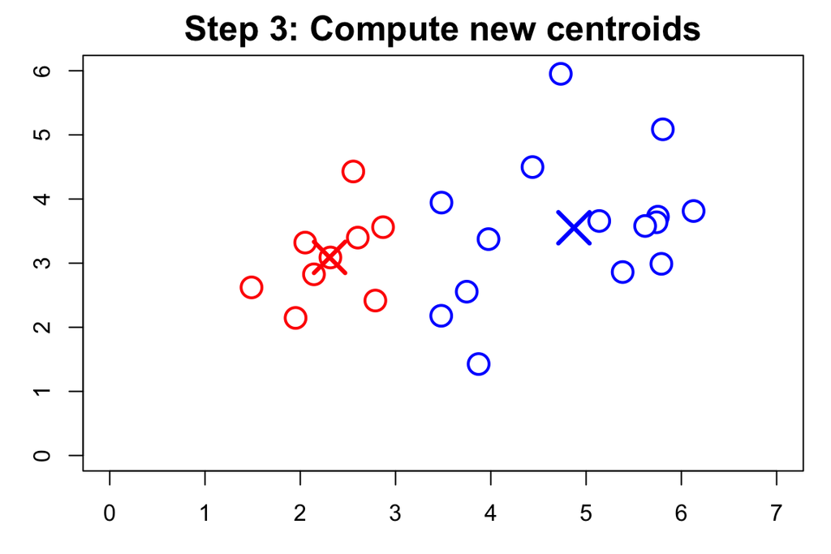

## K-means: Step 2 again

**Repeat Step 2** with updated centroids. If nothing changes we are done

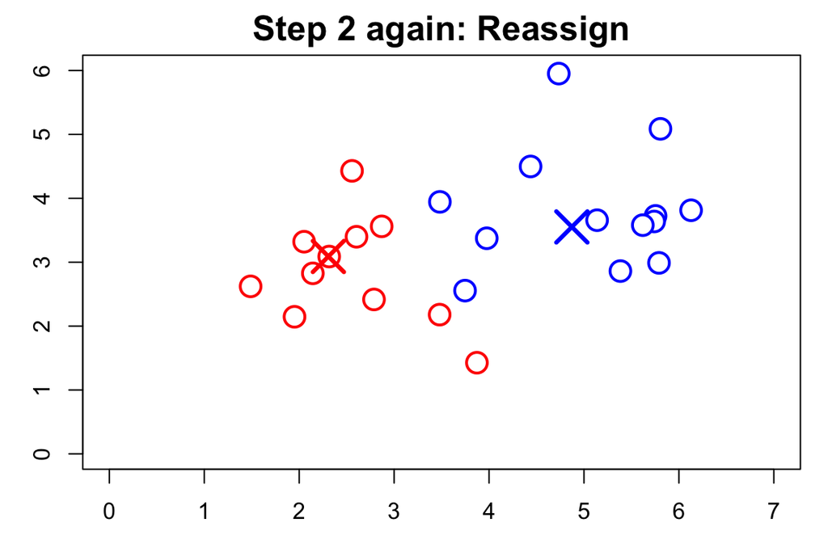

## K-means: Step 3 again

**Repeat Step 3**: recompute centroids.

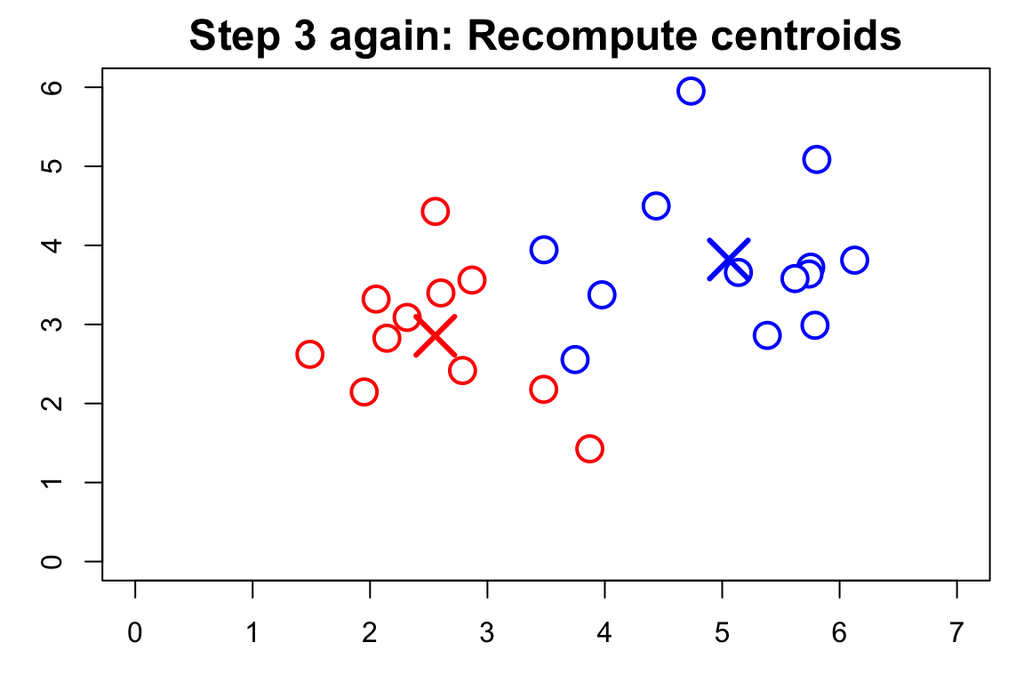

## K-means: Convergence

If assignments not changing, the algorithm **converged**. In R:

```r
km_final <- kmeans(X, centers = 2, nstart = 100)
```

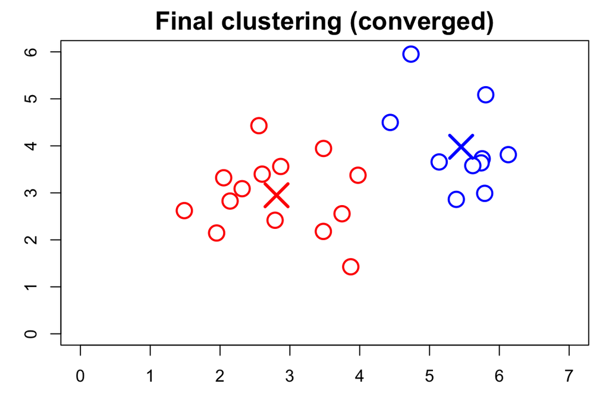

## K-means on the iris data (R-code)

```r
df <- data.frame(x=iris[,3], y=iris[,1])
kmeans_result <- kmeans(df, centers = 3,nstart = 100)
```

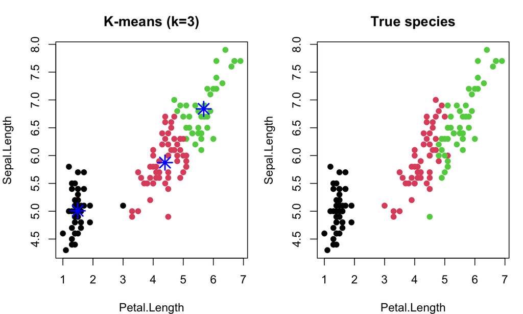

## K-means sums of squares

```r
kmeans_result$size # Cluster Sizes
```

```
## [1] 51 41 58
```

```r
kmeans_result$withinss # Within Cluster Sum of Squares
```

```
## [1]  9.893725 20.407805 23.508448
```

```r
kmeans_result$tot.withinss # Total Within Sum of Squares
```

```
## [1] 53.80998
```

**Interpretation:** - `size`: number of observations in each cluster - `withinss`: sum of squared distances within each cluster - `tot.withinss`: total variation within clusters (lower is better)

## K-means on the full iris data (R-code)

```r
df <- iris[,1:4]
kmeans_result <- kmeans(df, centers = 3,nstart = 100)
```

## K-means sums of squares

```r
kmeans_result$size          # Cluster Sizes
```

```
## [1] 62 38 50
```

```r
kmeans_result$withinss      # Within Cluster Sum of Squares
```

```
## [1] 39.82097 23.87947 15.15100
```

```r
kmeans_result$tot.withinss  # Total Within Sum of Squares
```

```
## [1] 78.85144
```

## Choosing K: Elbow Plot

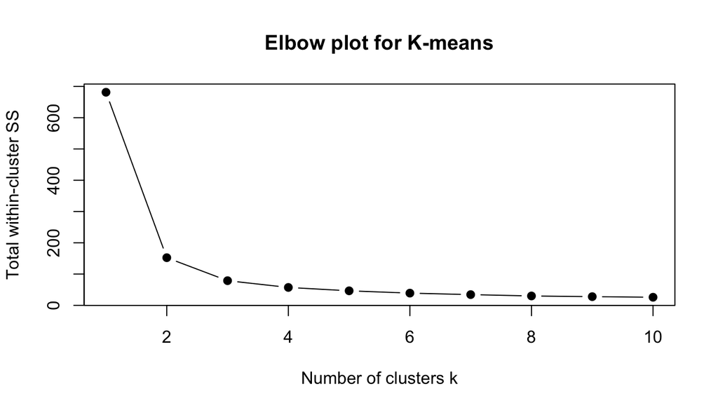

**Look for the “elbow”** where adding more clusters gives diminishing returns.

## AIC and BIC for K-means

\(\text{WCSS}_K = \texttt{km\$tot.withinss}\) be the residual sum of squares and \(\widehat{\sigma}^2_K = \text{WCSS}_K / n\) the variance.

Number of parameters: \(\text{params}_K = K \times p + 1\) (\(K\) of \(p\)-dimensional cluster means plus one common variance). Then\[ \text{AIC}(K) = n \log\left(\frac{\text{WCSS}_K}{n}\right) + 2\,\text{params}_K, \] \[ \text{BIC}(K) = n \log\left(\frac{\text{WCSS}_K}{n}\right) + \log(n)\,\text{params}_K. \]

- The term \(n \log(\text{WCSS}_K / n)\) plays the role of a (negative) log-likelihood based on the residual sum of squares.
- The penalty terms \(2\,\text{params}_K\) (AIC) and \(\log(n)\,\text{params}_K\) (BIC) discourage using too many clusters.

## Choosing K: AIC and BIC

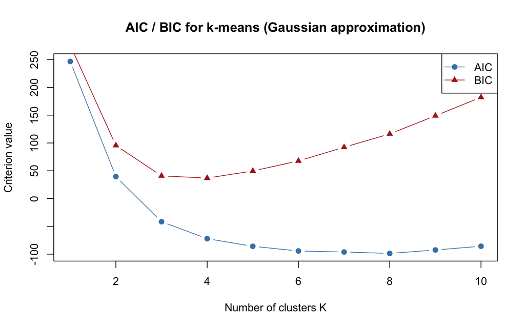

## Partitioning Around Medoids (PAM)

- The `kmeans()` function in always uses **Euclidean** distances.
- The `pam()` function (package `cluster`) is similar to k-means, but
  - Uses **medoids** instead of centroids (an actual data point closest to the center).
  - You can supply any distance **matrix** here.

\[ W_k = \sum_{i \in C_k} d(\mathbf{x}_i, \mathbf{m}_k) \quad\text{for cluster } C_k \]

Find clusters \(C_1, \dots, C_K\) such that \(\sum_{k=1}^K W_k\rightarrow\min\)

## PAM with custom distance matrix

PAM can work with **any dissimilarity matrix**, not just Euclidean distance.

```r
library(cluster)
set.seed(123)

# Use iris data
df <- iris[, c(3, 1)]# Petal.Length, Sepal.Length
pam_manhattan <- pam(df, k = 3, metric = "manhattan",nstart = 100)

# Compute Minkowski distance matrix
dist_minkowski <- dist(df, method = "minkowski")
# Run PAM on the distance matrix
pam_minkowski <- pam(dist_minkowski, k = 3, diss = TRUE,nstart = 100)
```

## PAM clustering on iris data

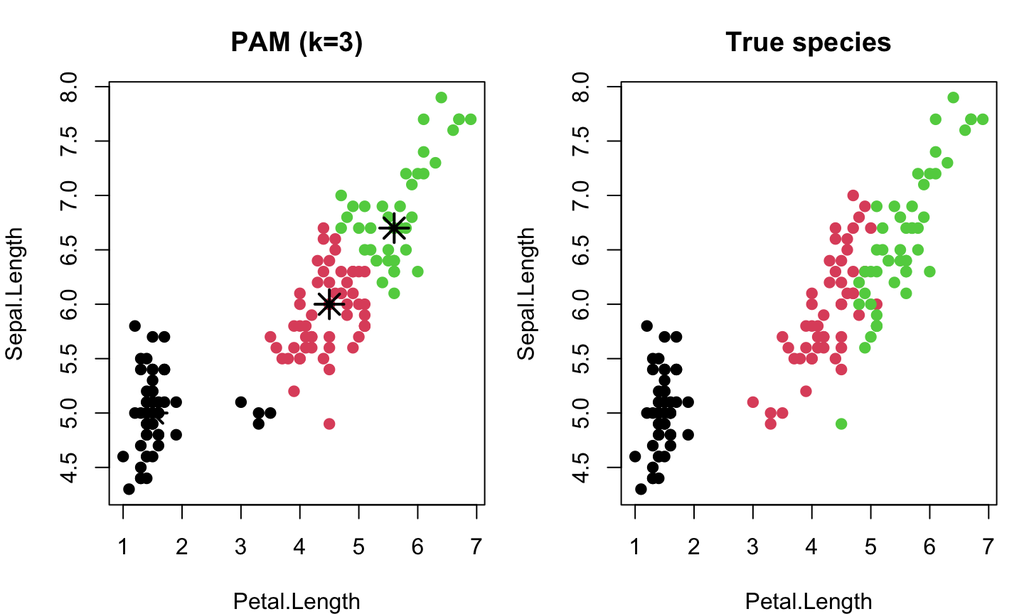

## Hierarchical clustering

- Builds a hierarchical distance structure – dendrogram (tree)
  - We often plot this dendrogram
- Clustering into distinct groups by cutting the dendrogram
- Requires we define distance between clusters (linkage function)

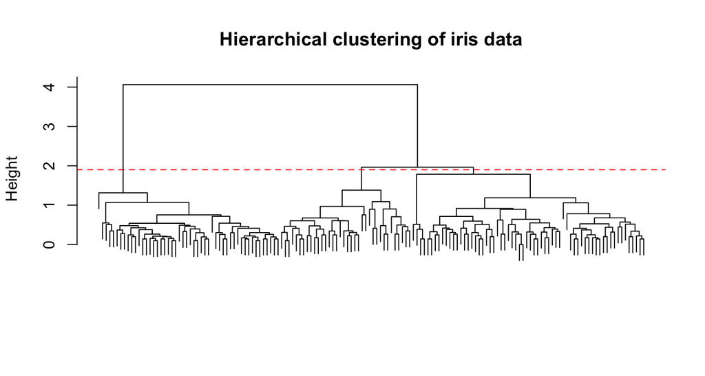

## Hierarchical clustering algorithm

Each of the \(n\) observations is a point in a \(p\)-dimensional space

**Agglomerative (bottom-up) algorithm to build a dendrogram:**

1. **Initialize**: Start with \(n\) clusters, with single observations.
2. **Compute distances**: Calculate the distance between every pair of clusters using a chosen **distance metric**.
3. **Merge**: Find the two clusters with the smallest distance and merge them into a single cluster.
4. **Update distances**: Recompute distances between the new cluster and all remaining clusters using a **linkage function**
5. **Repeat**: Go back to step 3 until all observations belong to a single cluster.

## Agglomeration method

The three common distance measures between groups are:

1. Single: Distance between groups = distance between closest group members
2. Average: Distance between groups = distance between group average points
3. Complete: Distance between groups = distance between most distant group members

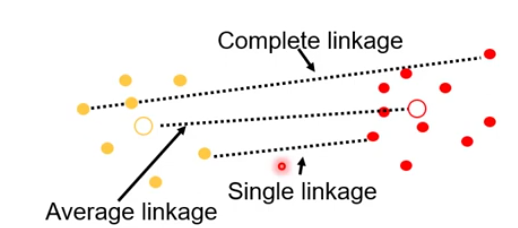

## Single Linkage: Initial Points

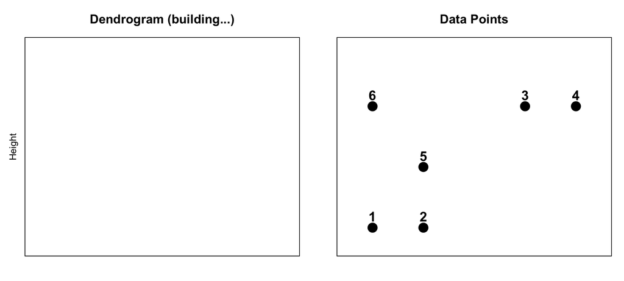

**6 clusters** (each point is its own cluster)

## Single Linkage: Step 1 (merge 1 & 2)

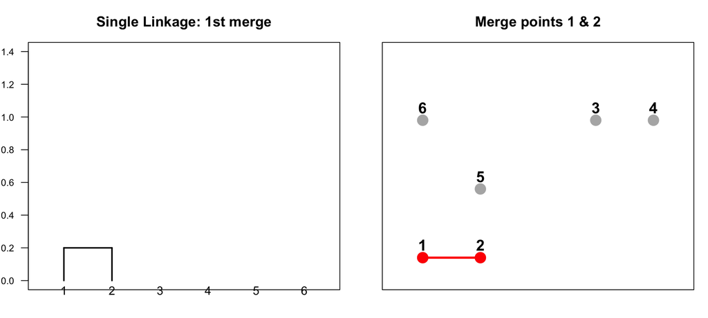

**Closest pair**: Points 1 & 2 (distance = 0.20) → **5 clusters**

## Single Linkage: Step 2 (merge 3 & 4)

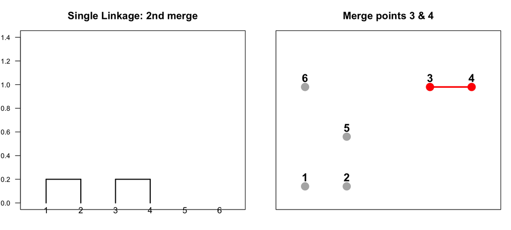

**Next closest pair**: Points 3 & 4 (distance = 0.20) → **4 clusters**: {1,2}, {3,4}, {5}, {6}

## Single Linkage: Step 3 (5 joins {1,2})

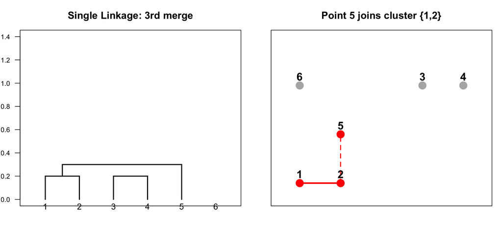

**Point 5** joins {1,2} at height ≈ 0.30 → **3 clusters**: {1,2,5}, {3,4}, {6}

## Single Linkage: Step 4 (6 joins {1,2,5})

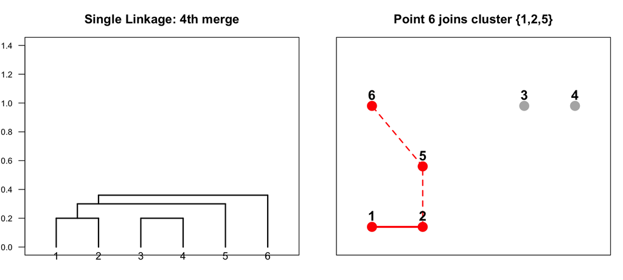

**Point 6** joins {1,2,5} at height ≈ 0.36 (nearest neighbor is point 5) → **2 clusters**: {1,2,5,6}, {3,4}

## Single Linkage: Step 5 (final merge)

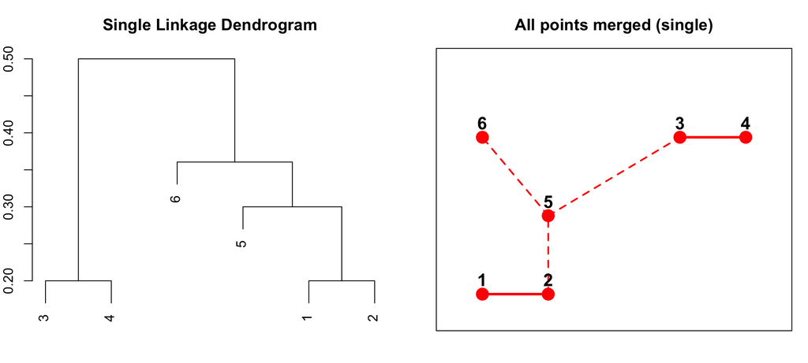

**Final merge**: Clusters {1,2,5,6} and {3,4} join at height ≈ 0.50 → **1 cluster**

## Complete Linkage: Initial Points

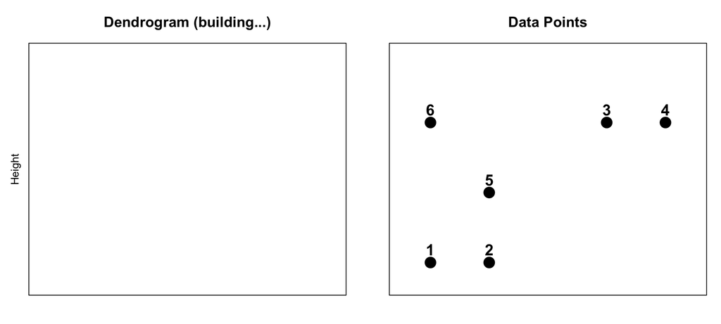

**6 clusters** (each point is its own cluster)

## Complete Linkage: Step 1 (merge 1 & 2)

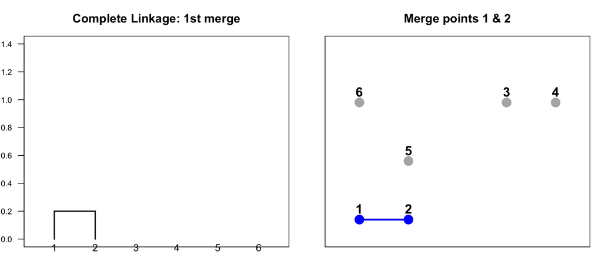

**Closest pair**: Points 1 & 2 (distance = 0.20) → **5 clusters**

## Complete Linkage: Step 2 (merge 3 & 4)

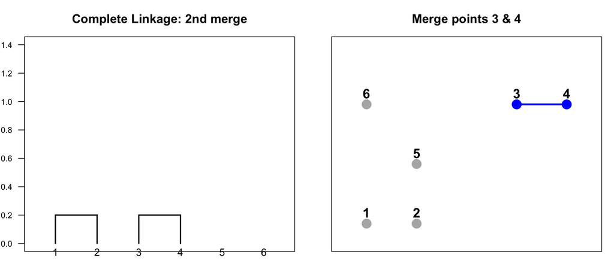

**Next closest pair**: Points 3 & 4 (distance = 0.20) → **4 clusters**: {1,2}, {3,4}, {5}, {6}